# EDA

Rita Li

2023-09-28

```r
library(tidyverse)
library(dplyr)
library(ggthemes)
library(hrbrthemes)
```

```r
flight_all <- read_csv("flightALL.csv")
```

## Airline Details

```r
flight_all %>%
  count(Operating_Airline) %>%
  arrange(n)
```

| Operating_Airline | n |
| --- | --- |
| G4 | 79 |
| QX | 1340 |
| F9 | 1372 |
| B6 | 2455 |
| CP | 3998 |
| AS | 5479 |
| NK | 9603 |
| DL | 9764 |
| UA | 9792 |
| OO | 13723 |

[output cut: 2 more lines]

#### 1 Allegiant Air (G4)

Allegiant Air is a low-cost U.S. airline. Notable Events: ·Missing Departure Time (DepTime) data from July 18 to August 01. ·Operated 1 turn on Wednesdays and 2 turns on Saturdays. ·Initiated the LAX to LAS route on June 05, 2019. ·Faced economic challenges, resulting in negative profit in 2020, which almost led to the closure of the route.

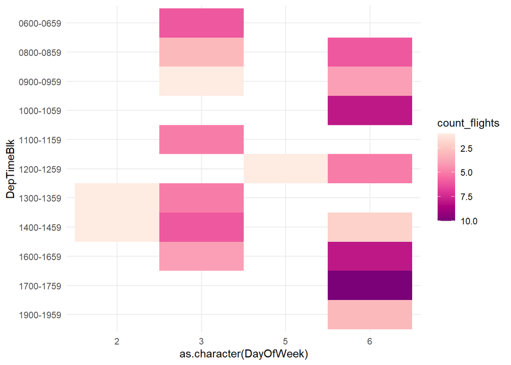

```r
flight_all %>%
  group_by(Operating_Airline, DayOfWeek, DepTimeBlk) %>%
  summarise(count_flights = n()) %>%
  filter(Operating_Airline == "G4") %>%
  ggplot(aes(y = DepTimeBlk, x = as.character(DayOfWeek), fill = count_flights))+
  geom_tile() +
  scale_fill_distiller(palette = "RdPu", trans = "reverse")+
  scale_y_discrete(limits=rev)+
  theme_minimal()
```

#### 2 Frontier Airlines (F9)

Frontier Airlines is another low-cost U.S. carrier. Notable Events: ·Operated 1 turn on this route daily. ·Experienced negative net profit in 2020. ·The route was possibly closed after July 14, though further investigation is needed to confirm the closure date.

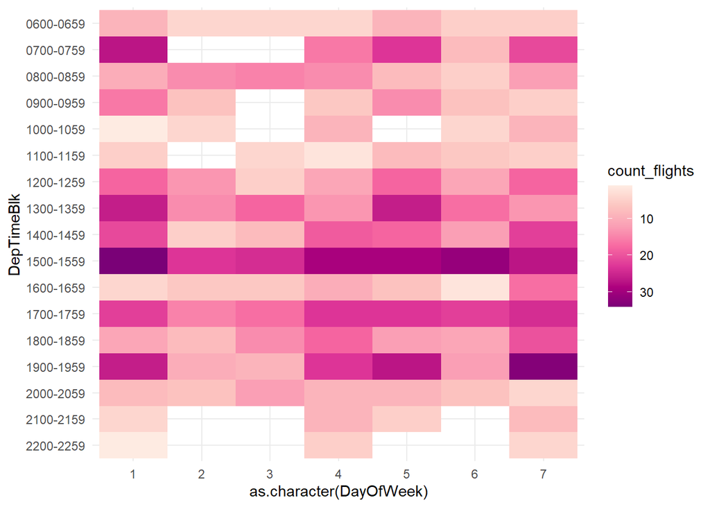

```r
flight_all %>%
  group_by(Operating_Airline, DayOfWeek, DepTimeBlk) %>%
  summarise(count_flights = n()) %>%
  filter(Operating_Airline == "F9") %>%
  ggplot(aes(y = DepTimeBlk, x = as.character(DayOfWeek), fill = count_flights))+
  geom_tile() +
  scale_fill_distiller(palette = "RdPu", trans = "reverse")+
  scale_y_discrete(limits=rev)+
  theme_minimal()
```

#### 3 Horizon Air (QX)

Horizon Air began operations on November 05, 2019, and continues to operate. It is affiliated with Alaska Airlines.

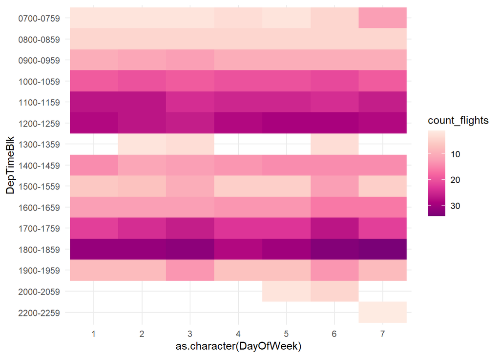

```r
flight_all %>%
  group_by(Operating_Airline, DayOfWeek, DepTimeBlk) %>%
  summarise(count_flights = n()) %>%
  filter(Operating_Airline == "QX") %>%
  ggplot(aes(y = DepTimeBlk, x = as.character(DayOfWeek), fill = count_flights))+
  geom_tile() +
  scale_fill_distiller(palette = "RdPu", trans = "reverse")+
  scale_y_discrete(limits=rev)+
  theme_minimal()
```

#### 4 JetBlue (B6)

JetBlue initiated service on October 07, 2020, and continues to operate on this route.

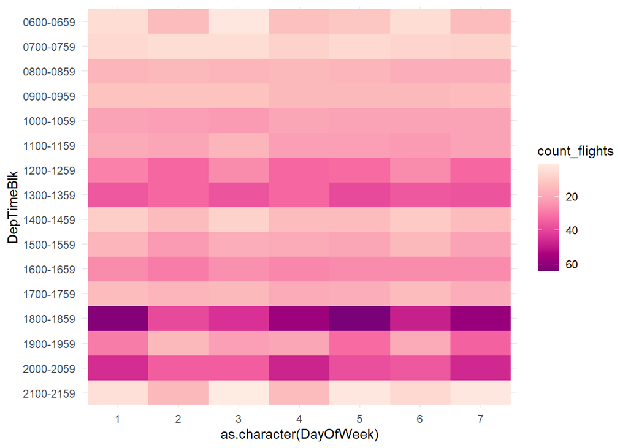

```r
flight_all %>%
  group_by(Operating_Airline, DayOfWeek, DepTimeBlk) %>%
  summarise(count_flights = n()) %>%
  filter(Operating_Airline == "B6") %>%
  ggplot(aes(y = DepTimeBlk, x = as.character(DayOfWeek), fill = count_flights))+
  geom_tile() +
  scale_fill_distiller(palette = "RdPu", trans = "reverse")+
  scale_y_discrete(limits=rev)+
  theme_minimal()
```

#### 5 Compass Airline (CP)

Compass Airline was associated with Delta. The route closed on April 1, 2020. Missing DepTime data for March 30, 2020, to March 31, 2020.

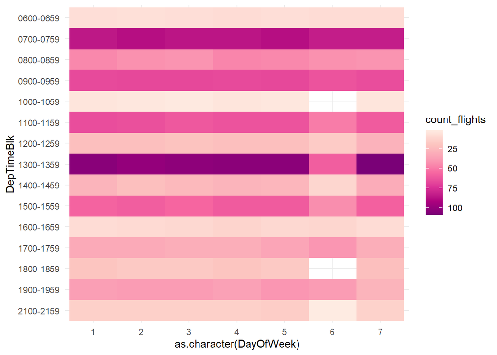

```r
flight_all %>%
  group_by(Operating_Airline, DayOfWeek, DepTimeBlk) %>%
  summarise(count_flights = n()) %>%
  filter(Operating_Airline == "CP") %>%
  ggplot(aes(y = DepTimeBlk, x = as.character(DayOfWeek), fill = count_flights))+
  geom_tile() +
  scale_fill_distiller(palette = "RdPu",, trans = "reverse")+
  scale_y_discrete(limits=rev)+
  theme_minimal()
```

#### Other Major Airliens

6. Southwest Airlines (WN)

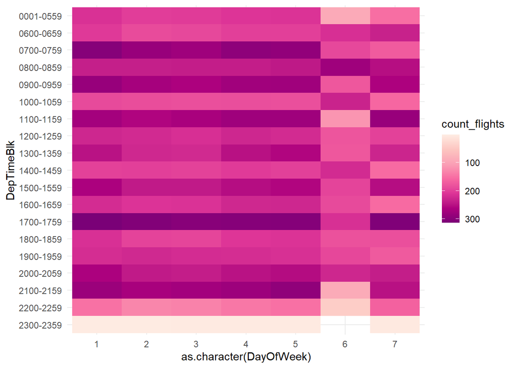

```r
flight_all %>%
  group_by(Operating_Airline, DayOfWeek, DepTimeBlk) %>%
  summarise(count_flights = n()) %>%
  filter(Operating_Airline == "WN") %>%
  ggplot(aes(y = DepTimeBlk, x = as.character(DayOfWeek), fill = count_flights))+
  geom_tile() +
  scale_fill_distiller(palette = "RdPu",trans = "reverse")+
  scale_y_discrete(limits=rev)+
  theme_minimal()
```

7. American Airlines (AA)

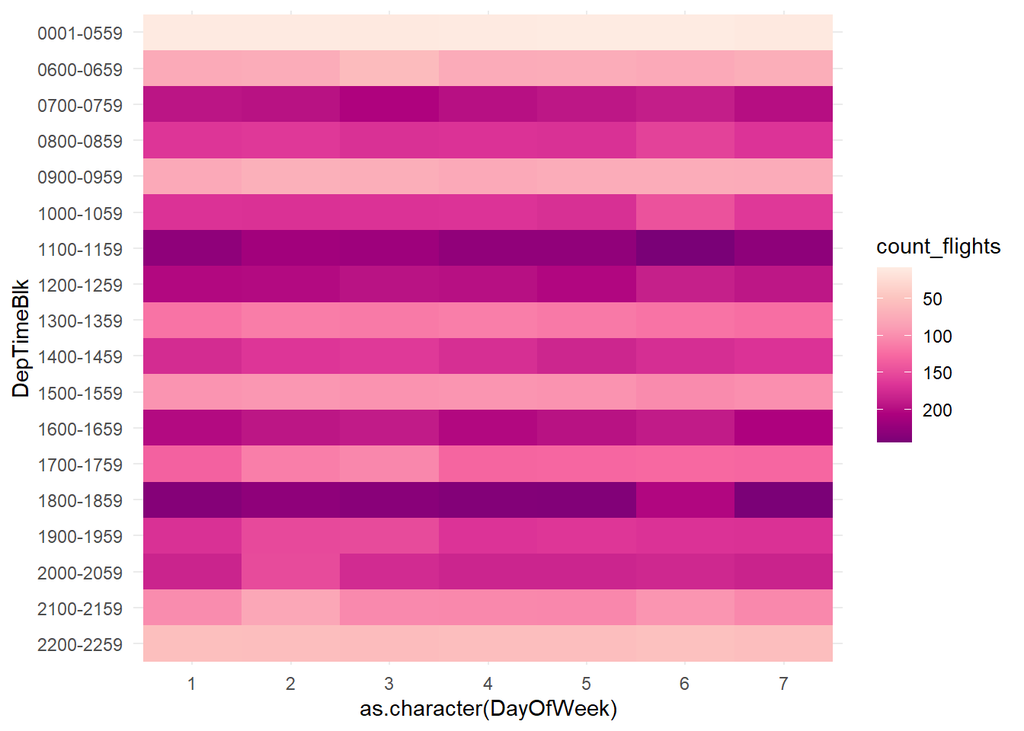

```r
flight_all %>%
  group_by(Operating_Airline, DayOfWeek, DepTimeBlk) %>%
  summarise(count_flights = n()) %>%
  filter(Operating_Airline == "AA") %>%
  ggplot(aes(y = DepTimeBlk, x = as.character(DayOfWeek), fill = count_flights))+
  geom_tile() +
  scale_fill_distiller(palette = "RdPu", trans = "reverse")+
  scale_y_discrete(limits=rev)+
  theme_minimal()
```

8. United Airlines (UA)

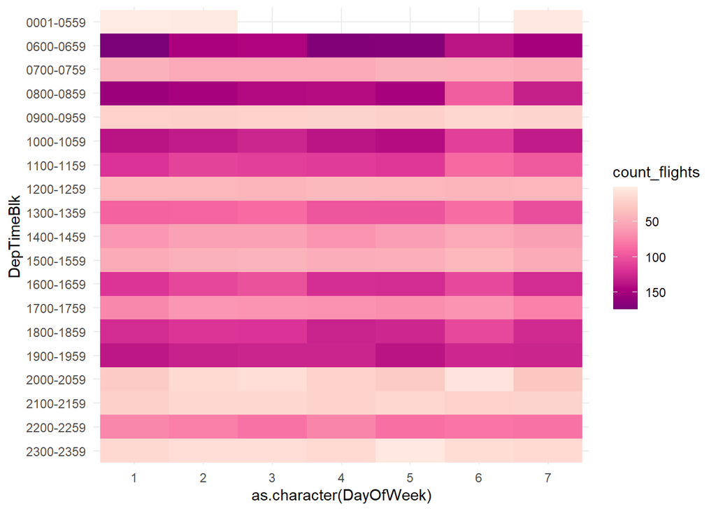

```r
flight_all %>%
  group_by(Operating_Airline, DayOfWeek, DepTimeBlk) %>%
  summarise(count_flights = n()) %>%
  filter(Operating_Airline == "UA") %>%
  ggplot(aes(y = DepTimeBlk, x = as.character(DayOfWeek), fill = count_flights))+
  geom_tile() +
  scale_fill_distiller(palette = "RdPu", trans = "reverse")+
  scale_y_discrete(limits=rev)+
  theme_minimal()
```

9. Delta Airines (DL)

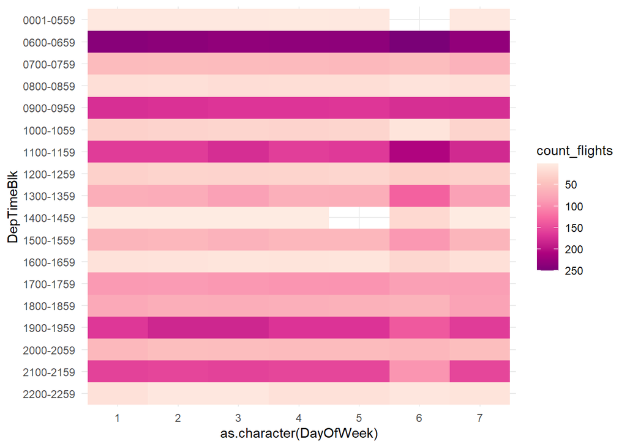

```r
flight_all %>%
  group_by(Operating_Airline, DayOfWeek, DepTimeBlk) %>%
  summarise(count_flights = n()) %>%
  filter(Operating_Airline == "DL") %>%
  ggplot(aes(y = DepTimeBlk, x = as.character(DayOfWeek), fill = count_flights))+
  geom_tile() +
  scale_fill_distiller(palette = "RdPu", trans = "reverse")+
  scale_y_discrete(limits=rev)+
  theme_minimal()
```

10. SkyWest Airlines (OO)

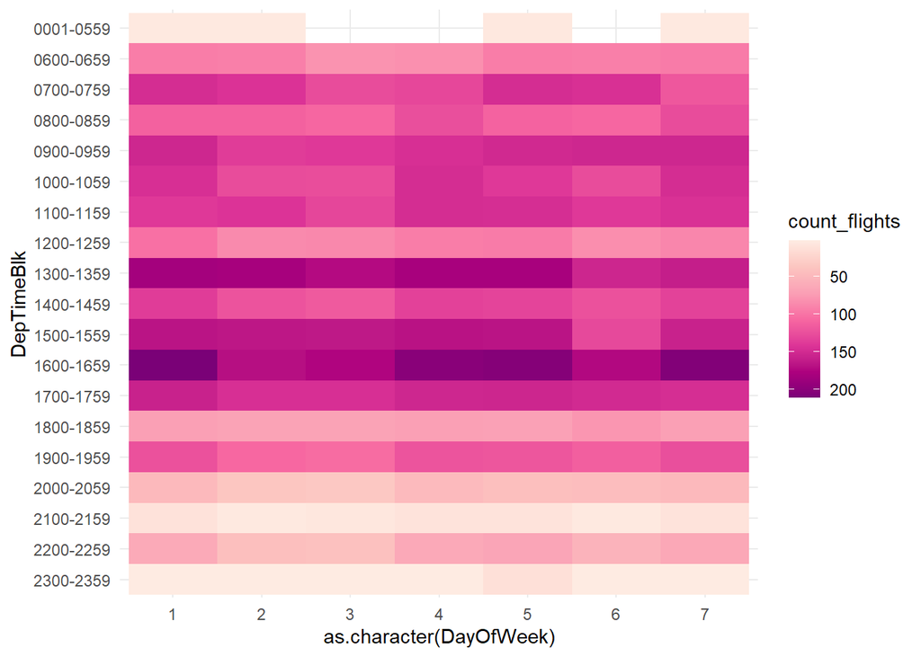

```r
flight_all %>%
  group_by(Operating_Airline, DayOfWeek, DepTimeBlk) %>%
  summarise(count_flights = n()) %>%
  filter(Operating_Airline == "OO") %>%
  ggplot(aes(y = DepTimeBlk, x = as.character(DayOfWeek), fill = count_flights))+
  geom_tile() +
  scale_fill_distiller(palette = "RdPu", trans = "reverse")+
  scale_y_discrete(limits=rev)+
  theme_minimal()
```

11. Spirit Airlines (NK)

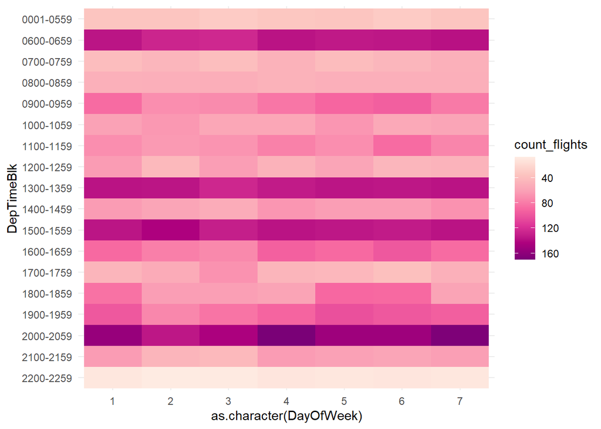

```r
flight_all %>%
  group_by(Operating_Airline, DayOfWeek, DepTimeBlk) %>%
  summarise(count_flights = n()) %>%
  filter(Operating_Airline == "NK") %>%
  ggplot(aes(y = DepTimeBlk, x = as.character(DayOfWeek), fill = count_flights))+
  geom_tile() +
  scale_fill_distiller(palette = "RdPu", trans = "reverse")+
  scale_y_discrete(limits=rev)+
  theme_minimal()
```

12. Alaska Airlines (AS)

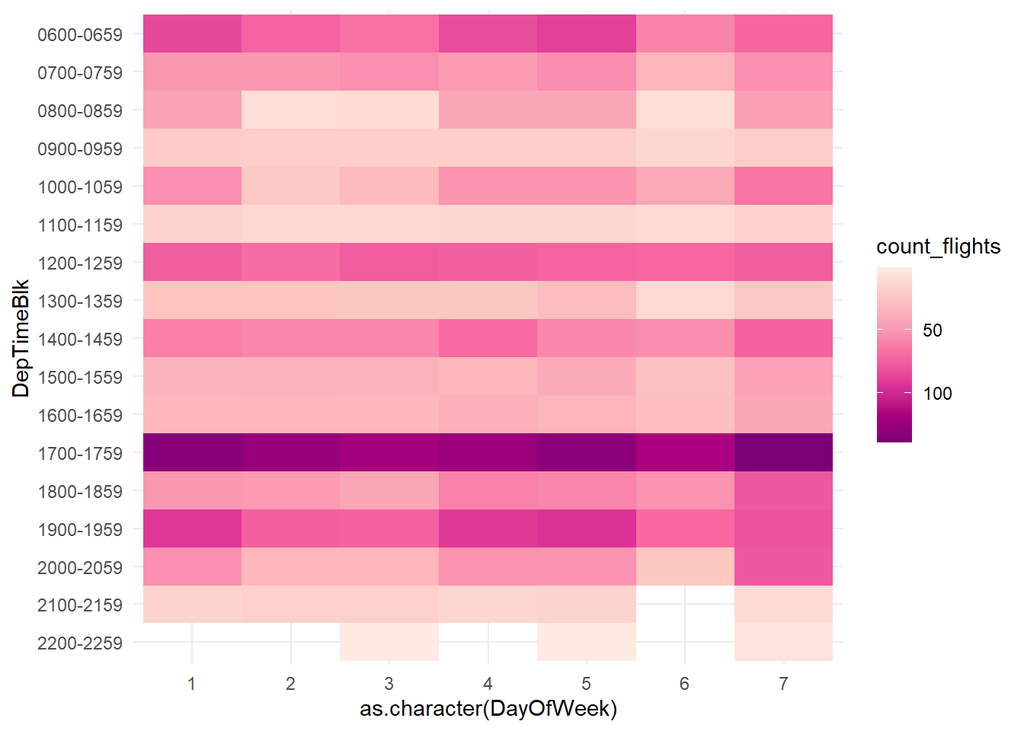

```r
flight_all %>%
  group_by(Operating_Airline, DayOfWeek, DepTimeBlk) %>%
  summarise(count_flights = n()) %>%
  filter(Operating_Airline == "AS") %>%
  ggplot(aes(y = DepTimeBlk, x = as.character(DayOfWeek), fill = count_flights))+
  geom_tile() +
  scale_fill_distiller(palette = "RdPu", trans = "reverse")+
  scale_y_discrete(limits=rev)+
  theme_minimal()
```

## Plots

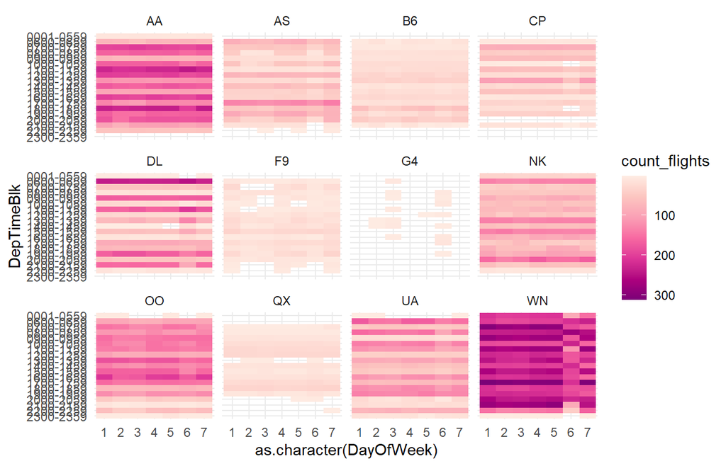

```r
flight_all %>%
  group_by(Operating_Airline, DayOfWeek, DepTimeBlk) %>%
  summarise(count_flights = n()) %>%
  # filter(Operating_Airline == "F9") %>%
  ggplot(aes(y = DepTimeBlk, x = as.character(DayOfWeek), fill = count_flights))+
  geom_tile() +
  scale_fill_distiller(palette = "RdPu", trans = "reverse")+
  scale_y_discrete(limits=rev)+
  theme_minimal()+
  facet_wrap(vars(Operating_Airline))
```

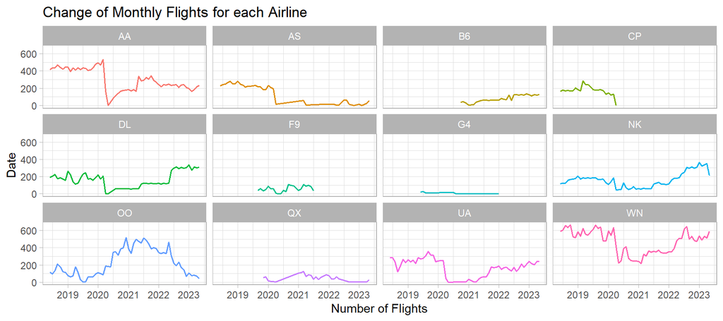

```r
flight_all %>%
  group_by(Year, Month, Operating_Airline) %>%
  summarise(num_of_flights = n()) %>%
  mutate(date = Year + (Month-1)/12) %>%
  ggplot(aes(x = date, y = num_of_flights, color = Operating_Airline)) +
  geom_line(size = 0.7)+
  labs(title = "Change of Monthly Flights for each Airline",
       x = "Number of Flights",
       y = "Date")+
  theme_light()+
  theme(legend.position = "none")+
  facet_wrap(vars(Operating_Airline))
```

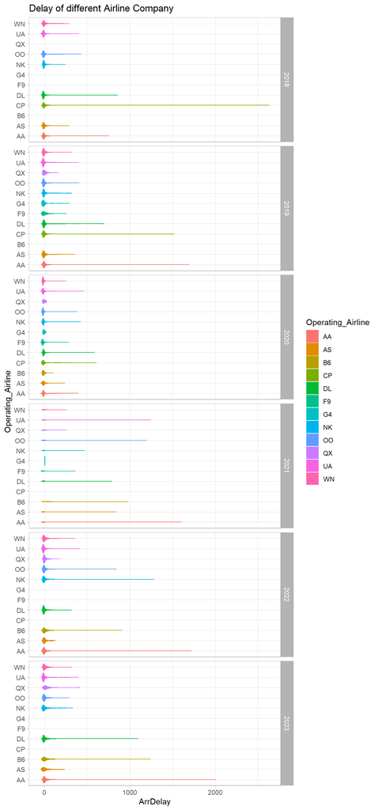

```r
flight_all %>%
  ggplot(aes(x = ArrDelay, y = Operating_Airline))+
  geom_violin(aes(fill = Operating_Airline, color = Operating_Airline))+
  theme_light()+
  labs(title = "Delay of different Airline Company")+
  facet_grid(vars(Year))
```